# 夜間光ラスターデータの可視化

日本周辺，1都3県の場合

[岩田真一郎](https://shinichiro-iwata.github.io/)（ [神奈川大学経済学部](https://www.econ.kanagawa-u.ac.jp/)）

2025-02-25作成，2025-03-02改定

# 1 目的

- [The Earth Observation Group (EOG)](https://eogdata.mines.edu/products/vnl/), Payne Institute for Public Policy, Colorado School of Minesが提供する夜間光データを地図上に可視化．夜間光データは経済活動の代理変数として経済学でも利用されている．特に地理（空間）的な経済活動を表すことに適している．
  - 夜間光データはラスター型．
    - ラスターデータ：セル（格子状の区画）で地理空間情報を表現するデータ形式．

パッケージ:`tidyverse`，`sf`，`terra`，`rnaruralearth`，`rmapshaper`

```r
library(tidyverse)
library(sf)

#夜間光データの読込など
library(terra)
#日本地図利用のため
library(rnaturalearth)
#sfオブジェクトの編集，簡略化
library(rmapshaper)
```

# 2 1992年の夜間光データの読込と日本周辺の可視化

## 2.1 夜間光データのダウンロードと読込

- 夜間光データは地球全体をカバーしているため，ファイルサイズが非常に大きく，ダウンロードに時間がかかる．[^1]
  - そこで，最初に[DMSP-F10](https://space.oscar.wmo.int/satellites/view/dmsp_f10)によって観測された1992年の夜間光データを使用，日本地図に可視化．
    - 解像度は30秒グリッド（約1km）のため，ファイルサイズが相対的に小さい（それでもPCの性能によっては時間がかかることに注意）．

**夜間光データのダウンロード**

- [DMSP-OLS](https://www.ngdc.noaa.gov/eog/dmsp/downloadV4composites.html) > Average Visible, Stable Lights, & Cloud Free Coverages > F101992
  - `Average Visible, Stable Lights, & Cloud Free Coverages`：雲のない夜の夜間光の平均値を記録．
  - `F101992`：[DMSP-F10](https://space.oscar.wmo.int/satellites/view/dmsp_f10)によって観測された1992年の夜間光データ．
- ダウンロードしたZIPファイルは作業フォルダ（ディレクトリ）に納め，ZIPファイルを選択 > 右クリック > すべて展開 > 展開先の選択とファイルの選択 > 展開を実行する．展開後は最初にダウンロードしたZIPファイルを削除．
  - 展開したファイルにはさらにたZIPファイルが格納されている．そのうち，`F101992.v4b_web.stable_lights.avg_vis.tif.gz`を「すべて展開」し作業フォルダに格納．
  - 利用するのは`F101992.v4b_web.stable_lights.avg_vis.tif`（夜間光の平均強度を示すデータ）．
  - `.tif`：画像ファイル形式の一つ．
- `terra`パッケージに含まれる`rast()`でデータを読込．オブジェクト名を`night1992`とする．

```r
#夜間光データの読込
night1992 <-
  rast("F101992.v4b_web.stable_lights.avg_vis.tif")
```

## 2.2 日本周辺の可視化

- 日本周辺の地図は[Natural Earth](https://www.naturalearthdata.com/)を利用．[^2]
  - インストールしていない場合は，`install.packages("rnaturalearth")`，`install.packages("rnaturalearthdata")`．
  - 世界地図（`World_map`）から日本地図（`Japan_map`）を切り抜き．

```r
World_map <-
  ne_countries(scale="medium")
```

```r
#緯度経度（数値のリスト）
fareast_box <- st_bbox(c(xmin=110,
                     xmax=155,
                     ymin=20,
                     ymax=50), crs=4326)
```

- `fareast_box`を`st_as_sfc()`でポリゴンにする．
- `st_intersects()`：`World_map`から`fareast_box_sfc`に収まる国（ポリゴン）を検索．`st_intersects()`を利用するには，オブジェクトが（マルチ）ポイント，（マルチ）ライン，（マルチ）ポリゴンである必要．
- `lengths()>0`: 重なるポリゴンを抽出しTRUEに．
- オブジェクト名を`fareast`とする．

```r
#sfcオブジェクト（四角形のポリゴン）の作成
fareast_box_sfc <- fareast_box %>%
  st_as_sfc()

#重なるポリゴン抽出
fareast <-
  lengths(st_intersects(World_map, fareast_box_sfc))>0
```

- `World_map`から`fareast==TRUE`を満たすメッシュを抽出（filter()）．
  - 第1引数`.`ですべての変数を残す．
  - オブジェクト名を`fareast_map`とする．
  - 異なるパッケージ間で関数名が競合しているため，`dplyr::filter()`と指示．

```r
fareast_map <- World_map %>%
  dplyr::filter(., fareast==TRUE)
```

**日本周辺の可視化**[^3]

- `coord_sf()`で範囲を指定しないと，東西の広い範囲を示してしまう．

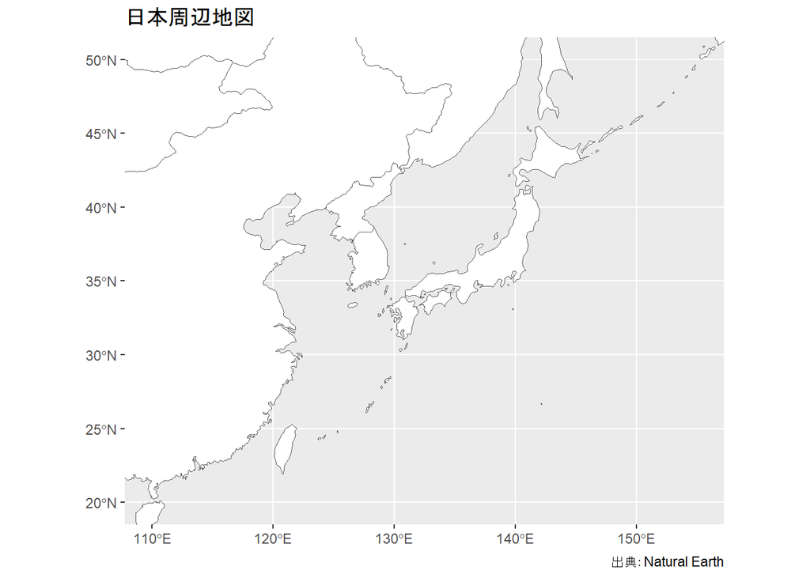

```r
ggplot()+
  geom_sf(data=fareast_map, fill="white")+
  coord_sf(xlim = c(110, 155), ylim = c(20, 50))+
  labs(caption="出典：Natural Earth")+
  ggtitle("日本周辺地図")
```

## 2.3 日本周辺の夜間光

- 読み込んだ夜間光データ`night1992`の観測数は膨大なため，これを可視するのも時間がかかる．
  - まず，範囲（先ほど作成しした`fareast_box`）内で`night1992`を切り抜き，データフレームに変換して可視する．
  - `crop()`：`terra`パッケージに含まれる`crop()`で切り抜くデータを読込．こうすることで観測数を大きく減らせる．
  - `ext()`：切り抜く範囲（数値のリスト）の指示．ここでは，すでに作成した`fareast_box`を利用．

```r
night1992 <- night1992 %>%
  crop(ext(fareast_box))
```

```r
night1992_df <- night1992 %>%
  as.data.frame(xy=TRUE) %>%
  rename(light=3)
```

**日本周辺の夜間光データの可視化**

- `geom_raster()`：夜間光強度（`night1992_df`の`light`列）の可視化．
- `tran=sqrt`で夜間光強度の平方根を求める．平方根変換により暗いエリアの微妙な差違も可視．

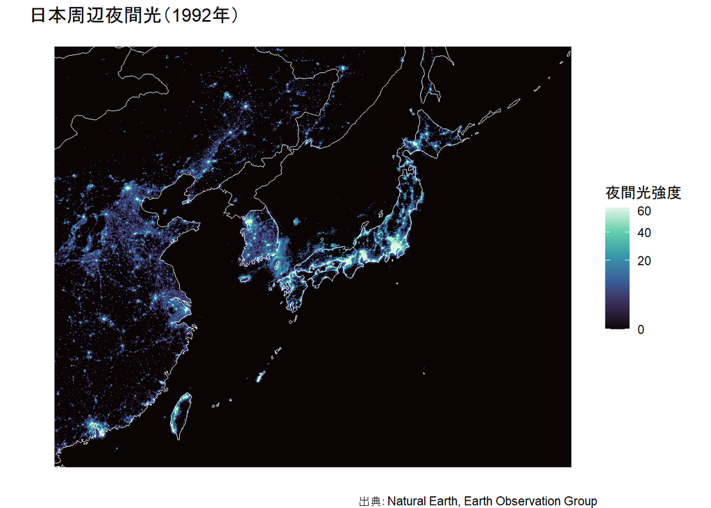

```r
ggplot() +
  geom_raster(data=night1992_df,
              aes(x=x, y=y, fill=light))+
  scale_fill_viridis_c(option="G", trans="sqrt")+
  geom_sf(data=fareast_map, fill=NA, color="white")+
  theme_void()+
  coord_sf(xlim=c(110, 155), ylim=c(20, 50)) +
  labs(fill="夜間光強度",
       caption="出典：Natural Earth, Earth Observation Group")+
  ggtitle("日本周辺夜間光（1992年）")
```

# 3 2020年の夜間光データの読込と1都3県の可視化

## 3.1 夜間光データのダウンロードと読込

- 次に[VIIRS](https://www.earthdata.nasa.gov/data/instruments/viirs)（2012年以降）が観測した夜間光データを使用，1都3県（2020年3月）に可視化．
  - 解像度は15秒グリッド（約500m）のため，ファイルサイズは大きくなった．
  - ただし，年平均だけではなく，月平均のデータ，地球全体（ファイルサイズが大きい）だけではなく，一部の地域だけのデータがダウンロード可能に⇒ファイルサイズが小さい（それでも時間は相当かかる）．
  - 利用には**ログイン**が必要に．

**夜間光データのダウンロード**

```r
# 夜間光データの読み込み
night203 <-
  rast("SVDNB_npp_20200301-20200331_75N060E_vcmslcfg_v10_c202007042300.avg_rade9h.tif")
```

## 3.2 1都3県（東京都離島除く）の可視化

- 1都3県の行政区域のシェープファイルを[国土数値情報](https://nlftp.mlit.go.jp/ksj/)からダウンロード．[^4]

```r
#行政区域の読込
Tokyo_map <- read_sf("N03-20220101_13_GML/N03-22_13_220101.shp")

Saitama_map <-
  read_sf("N03-20220101_11_GML/N03-22_11_220101.shp")

Chiba_map <-
  read_sf("N03-20220101_12_GML/N03-22_12_220101.shp")

Kanagagawa_map <-
  read_sf("N03-20220101_14_GML/N03-22_14_220101.shp")
```

- 東京都の離島を除き，1都3県を合併．
  - `bind_rows()`：列名の並び順が異なっても，揃えて結合．データは下に加えられてゆく．

```r
#離島の市町村ダミーの作成
Tokyo_map <- Tokyo_map %>%
  mutate(island=
           ifelse(N03_007>=13361 & N03_007<=13421,
                  1, 0))

#離島の市町村を除いたシェープファイルの作成
Tokyo_map <- Tokyo_map %>%
  subset(island!=1)

#1都3県合併
Greater_Tokyo <-
  bind_rows(Saitama_map, Chiba_map,
        Tokyo_map, Kanagagawa_map)
```

- このままだと，可視化した際の境界線は市区町村単位．境界線を県単位にする（見やすい？）．
  - `rmapshaper`パッケージの`ms_dissolve()`を使用．
  - `ms_dissolve()`：`N03_001`列に県名が記載されているので，県単位で境界を統合．

```r
#県単位で境界を統合
Greater_Tokyo <- Greater_Tokyo %>%
  ms_dissolve(field="N03_001")
```

- `crs`は夜間光データ（`nightGTY203`）に揃えて世界測地系（`4326`）．

```r
#CRSをJSD2011→WGS84（4326）
Greater_Tokyo <- Greater_Tokyo %>%
  st_transform(crs=4326)
```

**1都3県の可視化**

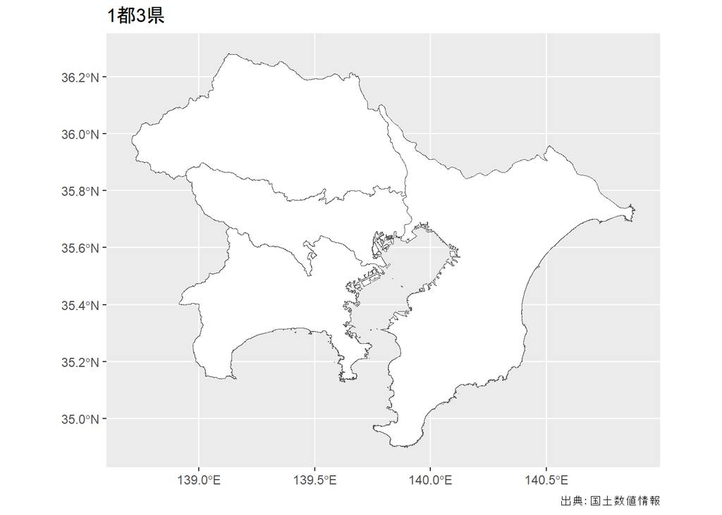

```r
ggplot()+
  geom_sf(data=Greater_Tokyo, fill="white")+
  labs(caption="出典：国土数値情報")+
  ggtitle("1都3県")
```

## 3.3 1都3県の夜間光

- 1都3県を含む範囲（`GreaterTY_box`）で`nightGTY203`を切り抜き，データフレームに変換して可視する．
- `st_bbox()`：境界ボックスの作成．
- `mask()`：ポリゴンに沿って不要な部分を`NA`に変更．
- `vect()`：`Greater_Tokyo`（sfオブジェクト）を`terra`の `SpatVector`に変換．

```r
#緯度経度（数値のリスト）
GreaterTY_box <- Greater_Tokyo %>%
  st_bbox()

#夜間光データを東京都にあわせて切り抜き
nightGTY203  <- night203 %>%
  crop(ext(GreaterTY_box))

#東京都の境界線に合わせて不要な部分を削除
nightGTY203  <- nightGTY203 %>%
  mask(vect(Greater_Tokyo))

#ggpolt()で可視するためデータフレームに変更
nightGTY203_df <- nightGTY203 %>%
  as.data.frame(xy=TRUE)%>%
  rename(light=3)
```

**1都3県の夜間光データの可視化**

- 夜間光強度は`nW/㎠/sr`（ナノワット／平方センチメートル／ステラジアン）．範囲は0以上の正の値であり，絶対的な値．

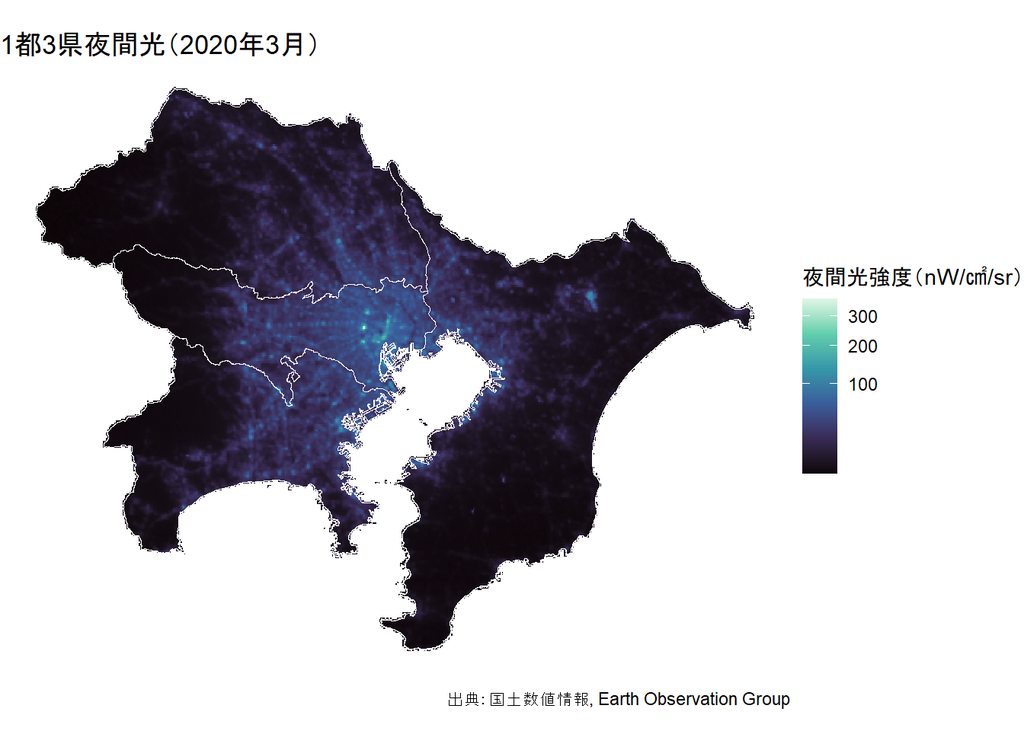

```r
ggplot()+
  geom_tile(data=nightGTY203_df,
            aes(x=x, y=y, fill=light))+
  scale_fill_viridis_c(option="G", trans="sqrt")+
  geom_sf(data=Greater_Tokyo, fill=NA, color="white")+
  theme_void()+
  labs(fill="夜間光強度（nW/㎠/sr）",
       caption="出典：国土数値情報, Earth Observation Group")+
  ggtitle("1都3県夜間光（2020年3月）")
```

# 4 応用：変化率の可視化

- 2020年3月と4月の夜間光強度の変化率を計算し，可視化．
- 2020年4月の夜間光データをダウンロードし，1都3県で切り抜き，データフレームに変換し，オブジェクト名を`nightGTY204_df`とする．
  - `nightGTY203_df`と合併し（オブジェクト名：`night_data`），変化率（`change_rate`）を求める．

```r
nightGTY203_df <- nightGTY203_df %>%
  rename(light_203=light)

nightGTY204_df <- nightGTY204_df %>%
  rename(light_204=light)

night_data <-
  left_join(nightGTY203_df, nightGTY204_df,
            by=c("x", "y"))

night_data <- night_data %>%
  mutate(change_rate=((light_204-light_203)/light_203)*100)
```

- 変化率の記述統計を示し，おおよその分布を把握．

|  | 平均 | 標準偏差 | 最小値 | 最大値 | 観察数 |
| --- | --- | --- | --- | --- | --- |
| 変化率（％） | 0.90 | 19.09 | -91.85 | 1244.68 | 77646 |

- 記述統計量を参考にカテゴリー化．[^5]

```r
night_data <- night_data %>%
  mutate(change_rate=case_when(
      change_rate>100 ~"(100, 1250)",
      change_rate>50 & change_rate<=100 ~ "(50, 100]",
      change_rate>10 & change_rate<=50 ~ "(10, 50]",
      change_rate>0 & change_rate<=10 ~ "(0, 10]",
      change_rate>-10 & change_rate<=0 ~ "(-10, 0]",
      change_rate>-50 & change_rate<=-10 ~ "(-50, -10]",
      change_rate>-100 & change_rate<=-50 ~ "(-100, -50]"))
```

- `factor()`を用いて凡例の順番を指定．

```r
night_data <- night_data %>%
  mutate(change_rate=factor(change_rate,
                            levels=c("(100, 1250)",
                                     "(50, 100]",
                                     "(10, 50]",
                                     "(0, 10]",
                                     "(-10, 0]",
                                     "(-50, -10]",
                                     "(-100, -50]")))
```

- `geom_sf()`を用いて可視するため，データフレームの`night_data`を`sf`オブジェクトに変換．

```r
night_data <- night_data %>%
  st_as_sf(coords=c("x", "y"), crs=4326)
```

**夜間光強度変化率の可視化**

- `scale_color_brewer()`：カテゴリーデータ（離散値）の色分け．

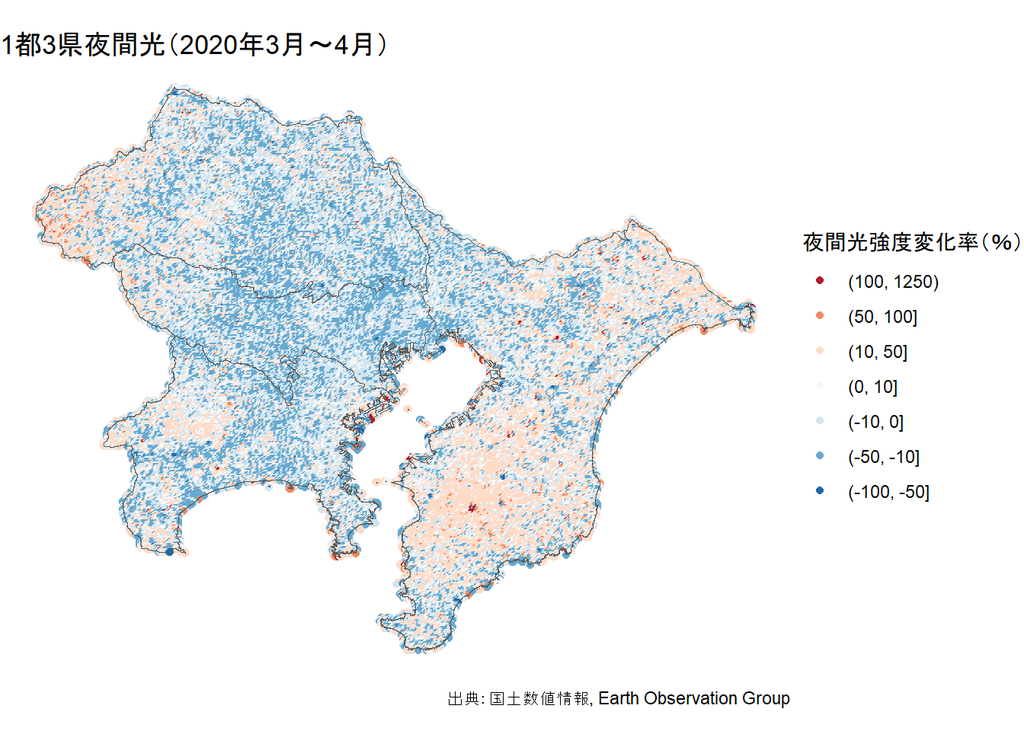

```r
ggplot() +
  geom_sf(data=night_data, aes(color=change_rate)) +
  scale_color_brewer(palette="RdBu")+
  geom_sf(data=Greater_Tokyo, fill=NA)+
  theme_void()+
  labs(color="夜間光強度変化率（％）",
       caption="出典：国土数値情報, Earth Observation Group") +
  ggtitle("1都3県夜間光（2020年3月～4月）")
```

**Rによる地理空間データの可視化**

チュートリアル[ホーム](https://shinichiro-iwata.github.io/geospatial-data-visualization/)

**アイコン**

Font Awesome 6.7.2

**生成AIの使用について**

作成過程において，ChatGPTを使用してコードの最適化に関する助言を得た．サービスを利用した後，内容を確認し，必要に応じて編集を行った．

[^1]: [Google Earth Engine](https://earthengine.google.com/)を用いて，必要な範囲だけを取得可能な模様．[Qitta](https://qiita.com/)←検索欄に検索ワード「Google Earth Engine 夜間光」を入力して検索．[神奈川大学経済学部浦沢聡士研究室](https://note.com/kuweb/n/n7f209f900b4c)もこのサービスを利用して夜間光データを可視化．
[^2]: [Natural Earth](https://www.naturalearthdata.com/)の利用方法の詳細は[Natural Earthの地理空間データの可視化](https://shinichiro-iwata.github.io/geospatial-data-visualization/rnaturalearth-visualization.html)参照．
[^3]: 地図の国境線については，学術誌（Elsevier，Wiley）では次のような注意書きが求められる場合がある．「Map lines delineate study areas and do not necessarily depict accepted national boundaries」．
[^4]: [市区町村データによる大学・大学院卒者割合の可視化](https://shinichiro-iwata.github.io/geospatial-data-visualization/municipality-data-visualization.html)参照
[^5]: カテゴリー化については[コミュニティバス路線上の人口密度の可視化](https://shinichiro-iwata.github.io/geospatial-data-visualization/community-bus-visualization.html)を参照．